# Etude du jeu de données de la base accidents corporels

Lou Hennenfent, Julia Mortier, Carl Nosland

01/12/2021

Notre script va explorer les données de la base accidents de la France entière. Il est composé de 5 jeux de données : - accidents.csv - caracteristiques-2020.csv - lieux-2020.csv - usagers-2020.csv - véhicules-2020.csv

- un jeu de données pour des analyses supplémentaires :

## BASE_TD_FILO_DEC_IRIS_2018.csv

## Setup

Definition du répertoire et chargement des librairies

Import des données

```r
caracteristiques <-
  read.csv("caracteristiques-2020.csv",
           sep = ";",
           fileEncoding = "UTF-8")
caracteristiques$Num_Acc <- as.character(caracteristiques$Num_Acc)

lieux <- read.csv("lieux-2020.csv", sep = ";")
lieux$Num_Acc <- as.character(lieux$Num_Acc)

usagers <-
  read.csv("usagers-2020.csv", sep = ";", fileEncoding = "UTF-8")
usagers$Num_Acc <- as.character(usagers$Num_Acc)
usagers$id_vehicule <- as.character(usagers$id_vehicule)

vehicules <-
  read.csv("vehicules-2020.csv",
           sep = ";",
           fileEncoding = "UTF-8")
vehicules$Num_Acc <- as.character(vehicules$Num_Acc)
vehicules$id_vehicule <- as.character(vehicules$id_vehicule)

length(unique(usagers$id_vehicule))
```

```
## [1] 79167
```

## Préparation des données

Catégoriser les vehicules selon le nombre de piétons / voitures heurtées

```r
vehicules_test <- vehicules %>%
  mutate(heurt_pietons = case_when(obsm == "1" ~ "1",
                                   TRUE ~ "0")) %>%
  mutate(heurt_voiture = case_when(obsm == "2" ~ "1",
                                   TRUE ~ "0")) %>%
  mutate(interdit = case_when(manv %in% c("5", "6", "7", "8", "10", "18", "25") ~ "1",
                              TRUE ~ "0"))
```

Changer le type de données pour pouvoir les sommer

```r
vehicules_test$heurt_pietons <-
  as.integer(vehicules_test$heurt_pietons)
vehicules_test$heurt_voiture <-
  as.integer(vehicules_test$heurt_voiture)
vehicules_test$interdit <- as.integer(vehicules_test$interdit)
```

Nombre de piétons et voitures heurtées par accident & nombre d’infractions

```r
vehicule_pieton <-
  aggregate(
    vehicules_test$heurt_pietons,
    by = list(Num_Acc = vehicules_test$Num_Acc),
    FUN = sum
  )
vehicule_voiture <-
  aggregate(
    vehicules_test$heurt_voiture,
    by = list(Num_Acc = vehicules_test$Num_Acc),
    FUN = sum
  )
vehicule_interdit <-
  aggregate(
    vehicules_test$interdit,
    by = list(Num_Acc = vehicules_test$Num_Acc),
    FUN = sum
  )
```

Ajouter les données de piétons et voitures dans les caracteristiques & nombre d’infractions

```r
caract_new <-
  merge(caracteristiques, vehicule_pieton, by = "Num_Acc") %>% rename(pieton = x)
caract_new <-
  merge(caract_new, vehicule_voiture, by = "Num_Acc") %>% rename(voiture = x)
caract_new <-
  merge(caract_new, vehicule_interdit, by = "Num_Acc") %>% rename(interdit = x)
```

Nettoyage des données

```r
rm(
  caracteristiques,
  vehicule_group,
  vehicule_group2,
  vehicule_interdit,
  vehicule_pieton,
  vehicule_voiture,
  vehicules,
  vehicules_test
)
```

## Recatégoriser les données

Catégoriser les usagers selon la gravité de blessure

```r
usagers_test <- usagers %>%
  mutate(mort = case_when(grav == "2" ~ "1",
                          TRUE ~ "0")) %>%
  mutate(hopital = case_when(grav == "3" ~ "1",
                             TRUE ~ "0")) %>%
  mutate(majeur = case_when(an_nais >= 2000 ~ "1",
                            TRUE ~ "0")) %>%
  mutate(mineur = case_when(an_nais < 2000 ~ "1",
                            TRUE ~ "0")) %>%
  mutate(traverse = case_when(actp == "3" ~ "1",
                              TRUE ~ "0"))
```

Changer le type de données pour pouvoir les sommer

```r
usagers_test$mort <- as.integer(usagers_test$mort)
usagers_test$hopital <- as.integer(usagers_test$hopital)
usagers_test$majeur <- as.integer(usagers_test$majeur)
usagers_test$mineur <- as.integer(usagers_test$mineur)
usagers_test$traverse <- as.integer(usagers_test$traverse)
```

Nombre de morts / hospitalisés / majeurs / mineurs / piétons traversants

```r
usagers_mort <-
  aggregate(usagers_test$mort,
            by = list(Num_Acc = usagers_test$Num_Acc),
            FUN = sum)
usagers_hopital <-
  aggregate(
    usagers_test$hopital,
    by = list(Num_Acc = usagers_test$Num_Acc),
    FUN = sum
  )
usagers_majeur <-
  aggregate(usagers_test$majeur,
            by = list(Num_Acc = usagers_test$Num_Acc),
            FUN = sum)
usagers_mineur <-
  aggregate(usagers_test$mineur,
            by = list(Num_Acc = usagers_test$Num_Acc),
            FUN = sum)
usagers_traverse <-
  aggregate(
    usagers_test$traverse,
    by = list(Num_Acc = usagers_test$Num_Acc),
    FUN = sum
  )
```

Ajouter les données de morts / hospitalisés / majeurs / mineurs / piétons traversants dans les caractéristiques

```r
caract_new <-
  merge(caract_new, usagers_mort, by = "Num_Acc") %>% rename(mort = x)
caract_new <-
  merge(caract_new, usagers_hopital, by = "Num_Acc") %>% rename(hopital = x)
caract_new <-
  merge(caract_new, usagers_majeur, by = "Num_Acc") %>% rename(majeur = x)
caract_new <-
  merge(caract_new, usagers_mineur, by = "Num_Acc") %>% rename(mineur = x)
caract_new <-
  merge(caract_new, usagers_traverse, by = "Num_Acc") %>% rename(traverse = x)
```

Jointure entre le dataset des caractéristiques et les lieux

```r
acc <-
  merge(caract_new, lieux[, c("Num_Acc", "catr", "surf", "situ", "vma")], by =
          "Num_Acc")
```

Nettoyage des données

```r
rm(
  usagers,
  usagers_hopital,
  usagers_majeur,
  usagers_mineur,
  usagers_mort,
  usagers_test,
  usagers_traverse
)
acc_ok <- acc %>% select(!adr)
rm(caract_new, lieux, acc)
```

##Exploration des donnees

```r
mois_num <- c(1, 2, 3, 4, 5, 6, 7, 8, 9, 10, 11, 12)
mois_abr <- c("J", "F", "M", "A", "M", "J", "J", "A", "S", "O", "N", "D")
```

Graphique : Nombre d’accidents avec pietons par mois en 2020

```r
AgregDate_p <-
  acc_ok %>% group_by(mois, jour) %>% summarise (nb = sum(pieton), mean = mean(pieton))
```

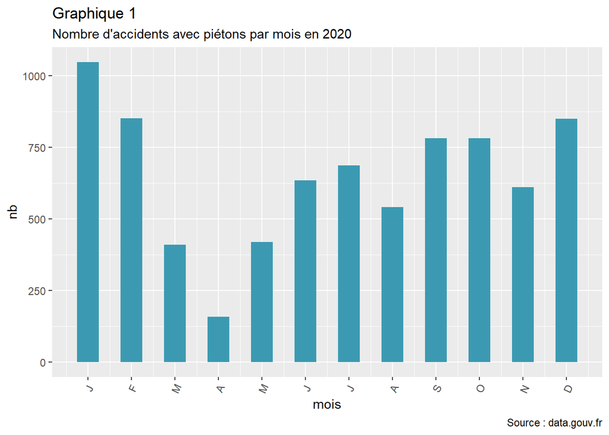

```r
ggplot(AgregDate_p, aes(mois, nb)) + geom_bar(stat = "identity",
                                              width = 0.5,
                                              fill = wes_palette("Zissou1", n = 1)) +
  labs(title = "Graphique 1",
       subtitle = "Nombre d'accidents avec piétons par mois en 2020",
       caption = "Source : data.gouv.fr") + scale_x_continuous(
         breaks = c(1, 2, 3, 4, 5, 6, 7, 8, 9, 10, 11, 12),
         labels = c("J", "F", "M", "A", "M", "J", "J", "A", "S", "O", "N", "D")
       ) +
  theme(axis.text.x = element_text(angle = 65, vjust = 0.6))
```

Graphique : Nombre d’accidents avec voiture par mois en 2020

```r
AgregDate_v <-
  acc_ok %>% group_by(mois, jour) %>% summarise (nb = sum(voiture), mean = mean(voiture))
```

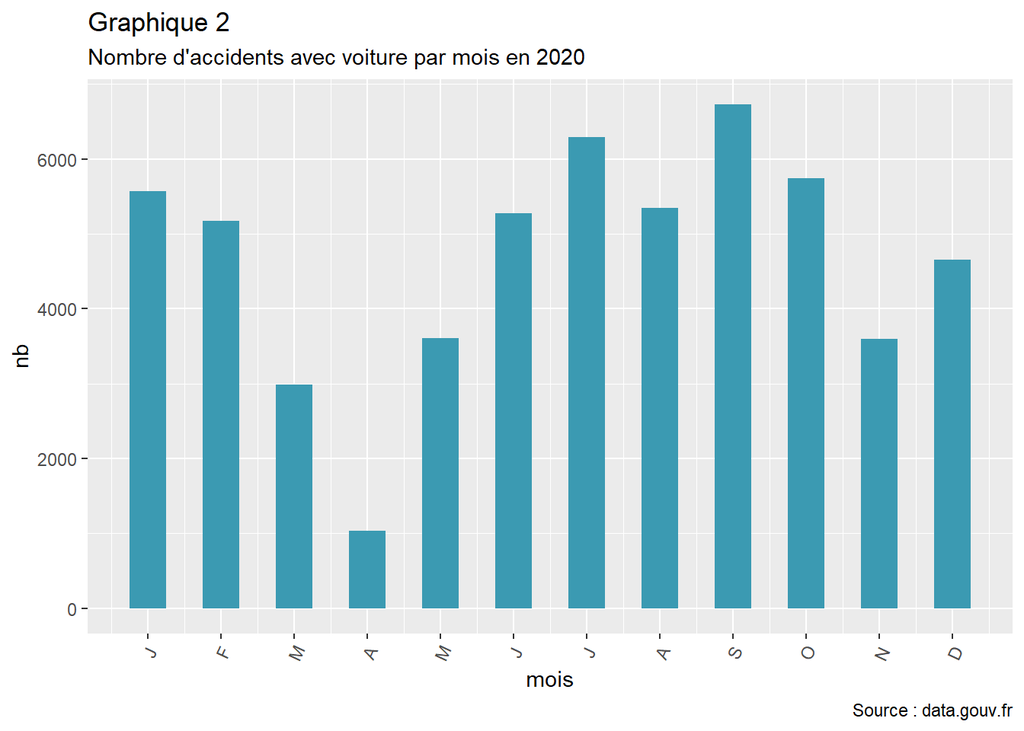

```r
ggplot(AgregDate_v, aes(mois, nb)) + geom_bar(stat = "identity",
                                              width = 0.5,
                                              fill = wes_palette("Zissou1", n = 1)) +
  labs(title = "Graphique 2",
       subtitle = "Nombre d'accidents avec voiture par mois en 2020",
       caption = "Source : data.gouv.fr") + scale_x_continuous(breaks =
                                                                            mois_num , labels = mois_abr) +
  theme(axis.text.x = element_text(angle = 65, vjust = 0.6))
```

Graphique : Nombre d’accidents mortels par mois en 2020

```r
AgregDate_m <-
  acc_ok %>% group_by(mois, jour) %>% summarise (nb = sum(mort), mean = mean(mort))
```

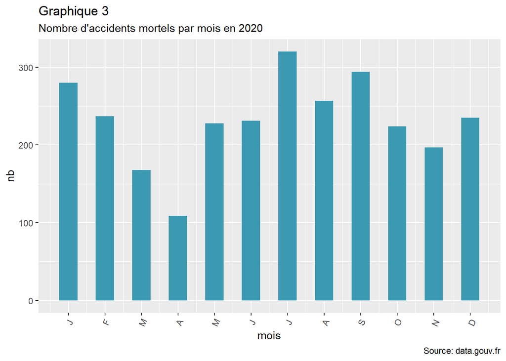

```r
ggplot(AgregDate_m, aes(mois, nb)) + geom_bar(stat = "identity",
                                              width = 0.5,
                                              fill = wes_palette("Zissou1", n = 1)) +
  labs(title = "Graphique 3",
       subtitle = "Nombre d'accidents mortels par mois en 2020",
       caption = "Source: data.gouv.fr") + scale_x_continuous(breaks =
                                                                            mois_num , labels = mois_abr) +
  theme(axis.text.x = element_text(angle = 65, vjust = 0.6))
```

Graphique : Répartition des accidents selon la Vitesse maximale autorisée

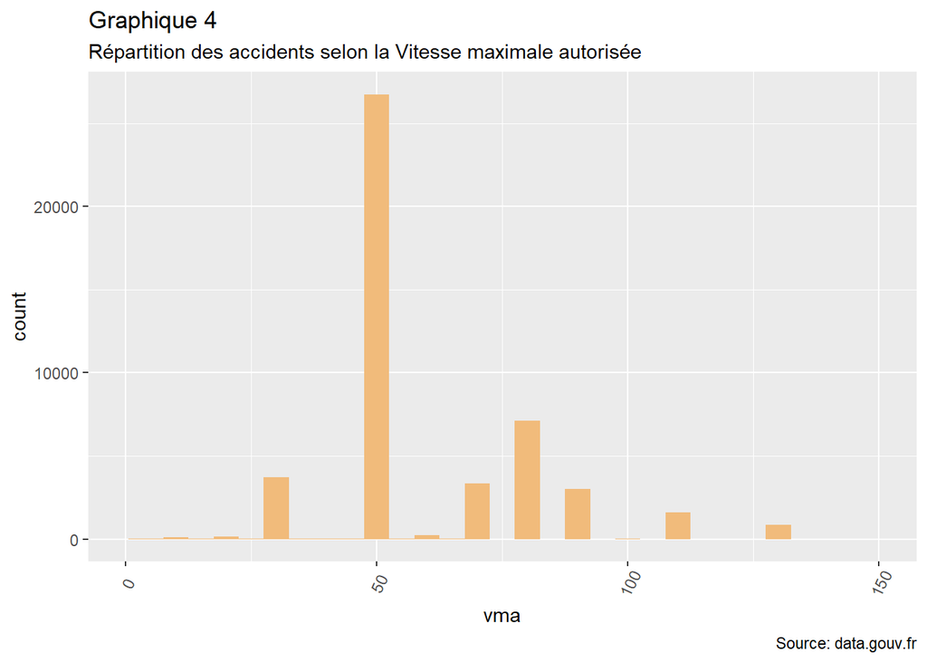

```r
AgregDate_vma <-
  acc_ok %>% group_by(vma) %>% summarize(count = n_distinct(Num_Acc))

ggplot(AgregDate_vma, aes(vma, count)) + geom_bar(stat = "identity",
                                                  width = 5,
                                                  fill = wes_palette("GrandBudapest1", n = 1)) +
  labs(title = "Graphique 4",
       subtitle = "Répartition des accidents selon la Vitesse maximale autorisée",
       caption = "Source: data.gouv.fr") + scale_x_continuous(limits = c(0,150)) +
  theme(axis.text.x = element_text(angle = 65, vjust = 0.6))
```

Graphique : Pourcentage d’accidents finissant à l’hopital par mois

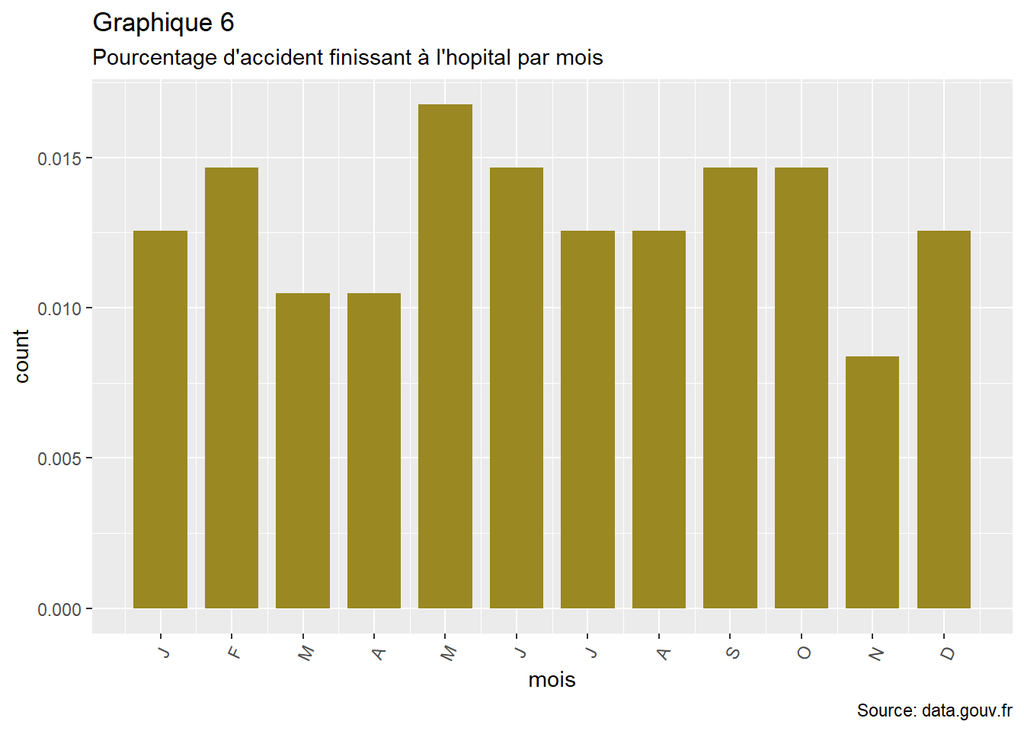

```r
AgregDate_hopital <-
  acc_ok %>% group_by(mois) %>% summarize(count = (n_distinct(hopital) /
                                                     47744) * 100)

ggplot(AgregDate_hopital, aes(mois, count)) + geom_bar(stat = "identity", width = 0.75, fill =
                                                         wes_palette("Royal2", n = 1)) +
  labs(title = "Graphique 6",
       subtitle = "Pourcentage d'accident finissant à l'hopital par mois",
       caption = "Source: data.gouv.fr") +scale_x_continuous(breaks =
                                                                           mois_num , labels = mois_abr) +
  theme(axis.text.x = element_text(angle = 65, vjust = 0.6))
```

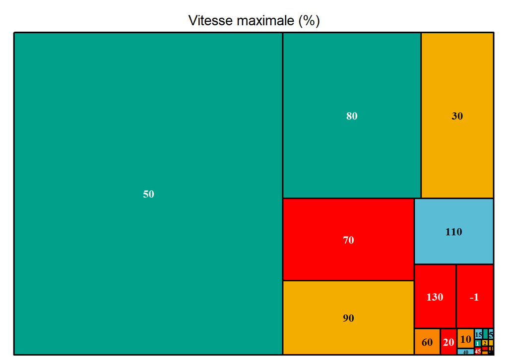

```r
AgregDate_vma <-
  acc_ok %>% group_by(vma) %>% summarize(count = n_distinct(Num_Acc))
treemap(
  AgregDate_vma,
  index = "vma",
  vSize = "count",
  type = "index",
  palette = wes_palette("Darjeeling1",n=5),
  title = " Vitesse maximale (%) ",
  title.legend ="",
  fontfamily.labels = "serif"
  )
```

Graphique : Treemap : Météo durant l’accident

```r
AgregDate_atm <-acc_ok %>% group_by(atm) %>% summarize(count = n_distinct(Num_Acc))
AgregDate_atm <- AgregDate_atm %>% filter(!(atm=='-1'))
AgregDate_atm <-AgregDate_atm %>% mutate(atmok = case_when(atm == "1" ~ "Normale",
                                                           atm == "2"~ "Pluie légère",
                                                           atm ==  "3" ~ "Pluie forte",
                                                           atm == "4" ~  "Neige",
                                                           atm == "5" ~  "Brouillard",
                                                           atm == "6" ~  "Vent fort",
                                                           atm == "7" ~  "Temps éblouissant",
                                                           atm == "8" ~  "Temps couvert",
                                                           atm == "9" ~  "Autre"))

treemap(
  AgregDate_atm,
  index = "atmok",
  vSize = "count",
  type = "index",
  palette = wes_palette("Darjeeling1",n=5),
  title = "Météo pendant l'accident",
  title.legend ="Pourcentage d'accident finissant à l'hopital par jour du mois",
  fontfamily.labels = "serif"
)
```

[figure not shown]

Graphique 3:Nombre d’accidents mortels par mois en 2020

```r
AgregDate_m <-acc_ok %>% group_by(mois, jour) %>% summarise (nb = sum(mort), mean = mean(mort))
```

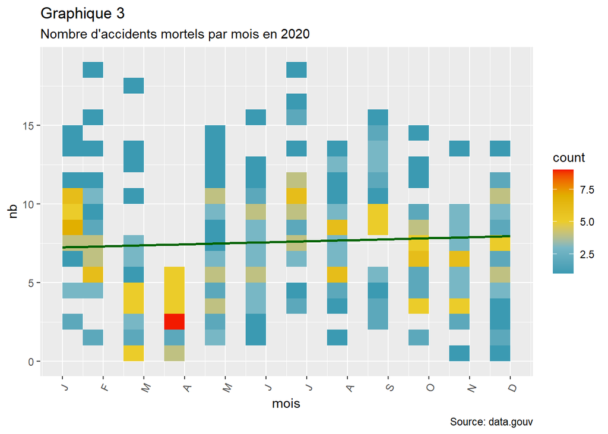

```r
ggplot(AgregDate_m, aes(x=mois, y=nb)) +  geom_bin2d(binwidth=c(0.5,1))  + scale_fill_gradientn( colours=wes_palette("Zissou1", n = 5)) + geom_smooth(method=lm,se=FALSE, color="darkgreen") +labs(title = "Graphique 3",subtitle = "Nombre d'accidents mortels par mois en 2020",caption = "Source: data.gouv") + scale_x_continuous(breaks = mois_num , labels = mois_abr) + theme(axis.text.x =element_text(angle = 65, vjust = 0.6))
```

# CARTOGRAPHIE

## 1.Préparation des données :

### Travail sur le tableur CSV du nombre d’accident :

```r
acc_okok <- acc_ok %>% filter(!(dep=='971'|dep== '972' |dep== '973' |dep=='974'|dep=='975'|dep=='976'|dep=='977'|dep=='978'|dep=='984'|dep== '986'|dep== '987'|dep=='988'|dep=='989'))
```

- Transformer notre fichier plat en fichier spatial (on veut transformer les données en objet SF) : Pour cela il nous faut une longitude et une latitude. Elle est déja renseignée dans la table acc_ok dans 2 champs différents.
  - Etapes pour changer le séparateur de latitude :

```r
acc_okok = acc_okok %>% separate(col = lat,into =c("lat1","lat2"),sep = ",")
acc_okok = acc_okok %>% unite("latok",lat1,lat2,sep = ".")
```

```r
acc_okok = acc_okok %>% separate(col = long,into =c("long1","long2"),sep = ",")
acc_okok = acc_okok %>% unite("longok",long1,long2,sep = ".")
```

- Etape pour passer d’un fichier plat à un ficher spatial

```r
acc_ok_sf = st_as_sf(acc_okok, coords=c("longok","latok"), crs=4326)
acc_spatial<- st_transform(acc_ok_sf, 2154)
```

### Travail sur les découpages administratifs :

- Importation des limites des arrondissements et garder uniquement les arrondissements de Paris et sa petite couronne

```r
ardt <- st_read(dsn = "ARRONDISSEMENT.shp", stringsAsFactors = FALSE)
#garder que les arrondissements de Paris :
ardtparis <- ardt %>% filter(CODE_DEPT == '75'| CODE_DEPT == '92' | CODE_DEPT == '93'| CODE_DEPT == '94')
```

- Importation des limites des communes et garder uniquement les communes de Paris et sa petite couronne

```r
com <- st_read(dsn = "COMMUNE.shp", stringsAsFactors = FALSE)
comparis <- com %>% filter(CODE_DEPT == '75'| CODE_DEPT == '92' | CODE_DEPT == '93'| CODE_DEPT == '94')
comparis<- st_transform(comparis, 2154)
```

- Importation des limites des iris et garder uniquement les IRIS de Paris et sa petite couronne

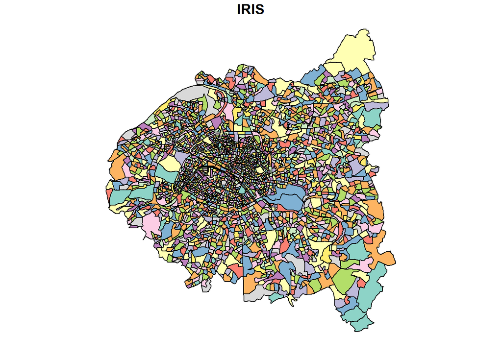

```r
iris <- st_read(dsn = "CONTOURS-IRIS.shp", stringsAsFactors = FALSE)
irisparis <- iris %>% filter(grepl("^75", INSEE_COM)| grepl("^92", INSEE_COM) | grepl("^93", INSEE_COM)| grepl("^94", INSEE_COM))
plot(irisparis["IRIS"])
```

```r
irisparis<- st_transform(irisparis, 2154)
```

## 2. Représentation cartographique

### Vue globale des accidents en France : carte interactive

```r
pal = colorNumeric("Rushmore", domain = acc_ok_sf$vma)
leaflet(data = acc_ok_sf) %>%
  addProviderTiles(providers$CartoDB.Positron) %>%
  addCircles(col = ~pal(catr), opacity = 0.9) %>%
  setView(lng = 2.442971, 46.913021, zoom = 6) %>%
  addMiniMap()
```

[interactive chart not shown]

### Comment sont répartis les accidents à paris ?

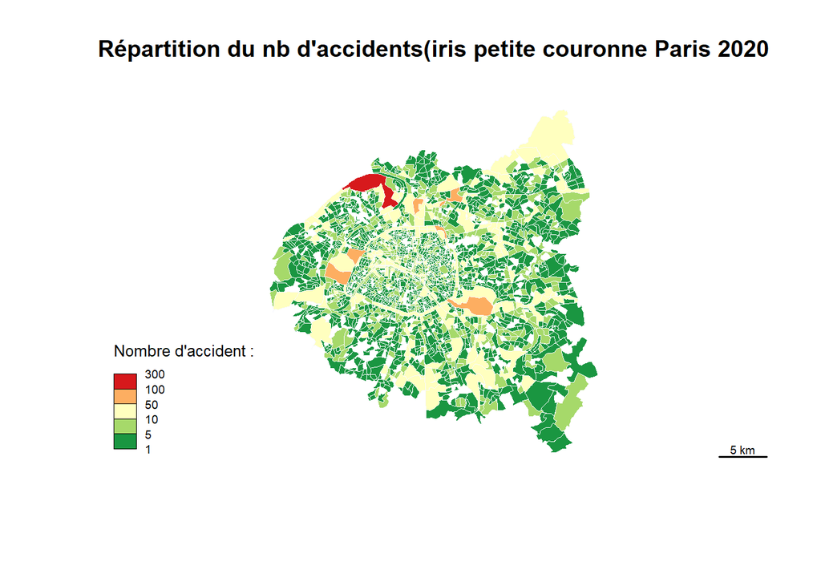

```r
acc_spatialIRISPARIS <- st_join(irisparis, acc_spatial)
parisokkk <- acc_spatialIRISPARIS %>% filter(dep == '75'| dep == '92' | dep == '93'| dep == '94')

okm <-parisokkk %>% group_by(CODE_IRIS) %>% summarise(accidents=n())
choroLayer(
  x = okm,
  var = "accidents",
  breaks = c(1, 5, 10, 50, 100, 300),
  col = c("#1a9641", "#a6d96a", "#ffffbf", "#fdae61", "#d7191c"),
  border = "#F9FAFD",
  lwd = 0.1,
  legend.title.txt = "Nombre d'accident :")
  barscale(size = 5)
  title(main = "Répartition du nb d'accidents(iris petite couronne Paris 2020")
```

### Carte catégorisée dans une grille

- Faire une grille

```r
grille <- st_make_grid(
  comparis,
  cellsize = 500,
  crs = 2154,
  what = "polygons",
  square = FALSE)
```

- Garder uniquement les carreaux qui sont sur notre zone d’étude (Paris)

```r
grille <- st_sf(grille)
grille <- grille %>% mutate(grilleok = lengths(st_intersects(grille, comparis)))
grille <- grille %>% filter(!grilleok=='0')
```

- Joindre les informations de la table des accidents dans la grille (jointure spatiale)

```r
acc_spatial <- st_join(grille, acc_spatial) %>% mutate(accidenthiver = case_when(mois == 2 ~ '1' ,mois == 1 ~ '1', mois == 3 ~ '1', mois == 12 ~'1' , TRUE  ~ '0'))
```

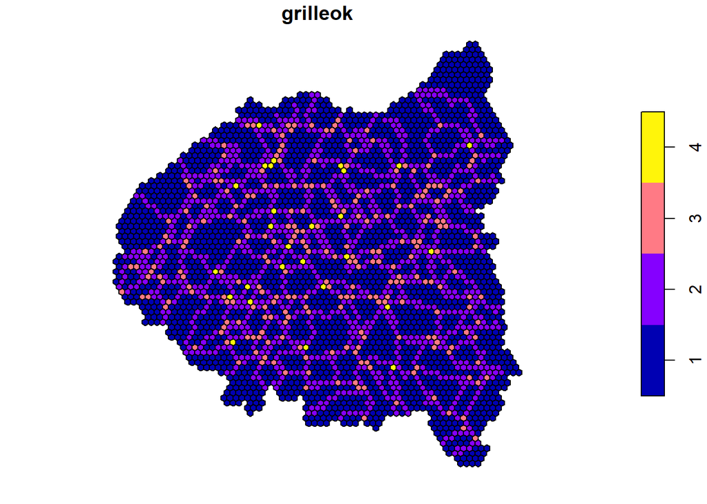

```r
grille <- st_make_grid(
    comparis,
    cellsize = 500,
    crs = 2154,
    what = "polygons",
    square = FALSE)

  grille <- st_sf(grille)
  grille <- grille %>% mutate(grilleok = lengths(st_intersects(grille, comparis)))
  grille <- grille %>% filter(!grilleok=='0')
  plot(grille)
```

```r
  acc_spatial_gri <- st_join(grille, acc_spatial)
```

Garder que les accident qui impliquent au moins un piéton

```r
 acc_spatial_gr <- acc_spatial_gri %>% filter(pieton == '1')
  acc_spatial_gr <- grille %>% mutate(grilleok = lengths(st_intersects(grille, acc_spatial)))

  choroLayer(
    x = acc_spatial_gr,
    var = "grilleok",
    breaks = c(1,20, 50, 100, 300),
    col = c("#1a9641", "#a6d96a", "#ffffbf", "#fdae61", "#d7191c"),
    border = "#F9FAFD",
    lwd = 0.1,
    legend.pos = "topleft",
    legend.title.txt = "Nombre de piétons :")

  layoutLayer(title = "Répartition du nombre d'accidents implicant un piéton ",
              sources = "Data.gouv.fr",
              author = "L.Hennenfent, N.nosland, J.mortier, 2020",  north = TRUE,
              frame = FALSE, col = "#cdd2d4", coltitle = "#8A5543")
```

[figure not shown]

- Réalisation cartographique ### Représentation du nombre d’accidents en fonction des saisons Dans un premier temps, il a fallu créer une nouvelle colonnes pour chaque saison et y attribuer des valeurs entre 1 et 0 en fonction de la saison où a eu lieu l’accident. Par exemple, si l’accident a eu lieu en décembre, on va affecter une valeur de 1 à la colonne de décembre et une valeur de 0 à la colonne d’été, printemps et automne.

```r
acc_spatialIRISPARIShiver <-parisokkk %>% mutate(accidenthiver = case_when(mois == 2 ~ '1' ,mois == 1 ~ '1', mois == 3 ~ '1', mois == 12 ~'1' , TRUE  ~ '0'))
acc_spatialIRISPARIShiver$accidenthiver <- as.numeric(acc_spatialIRISPARIShiver$accidenthiver)


acc_spatialIRISPARISete <-parisokkk %>% mutate(accidentete2 = case_when(mois == 8 ~ '1' ,mois == 9 ~ '1', mois ==  7 ~ '1', TRUE  ~ '0'))
acc_spatialIRISPARISete$accidentete2 <- as.numeric(acc_spatialIRISPARISete$accidentete2)


acc_spatialIRISPARISprint <-parisokkk %>% mutate(accidentprintemps2 = case_when(mois == 4 ~ '1' ,mois == 5 ~ '1', mois ==  6 ~ '1', TRUE  ~ '0'))
acc_spatialIRISPARISprint$accidentprintemps2 <- as.numeric(acc_spatialIRISPARISprint$accidentprintemps2)


acc_spatialIRISPARISauto <-parisokkk %>% mutate(accidentautomne2 = case_when(mois == 10 ~ '1' ,mois == 11 ~ '1',TRUE  ~ '0'))
acc_spatialIRISPARISauto$accidentautomne2 <- as.numeric(acc_spatialIRISPARISauto$accidentautomne2)
```

Dans un second temps nous avons compté le nombre d’accidents qu’il y a eu pour chaque saison par iris. Pour cela, nous avons donc regroupé l’information à l’aide d’un groupe_by puis nous avons résumé cette information avec un summarise (ce qui nous a permis de faire la somme du nombre d’accident par IRIS).

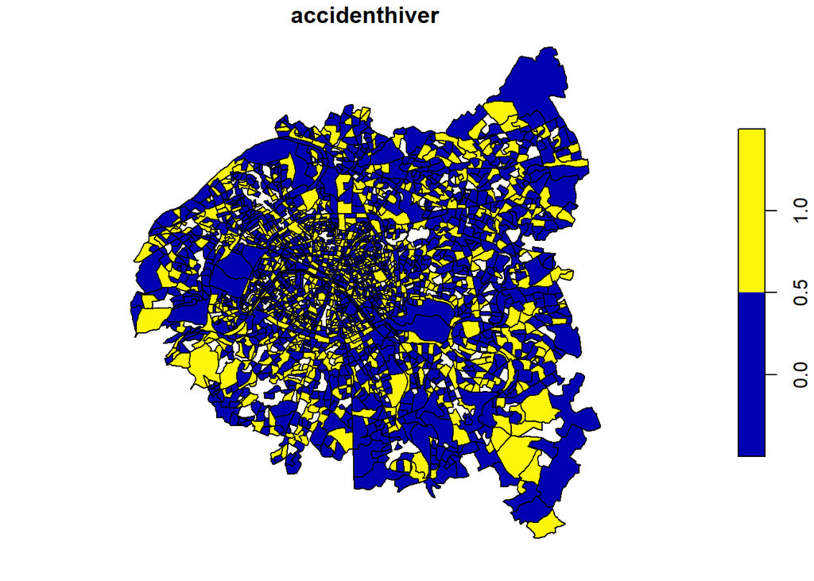

```r
acc_spatialIRISPARIShiver2 <-acc_spatialIRISPARIShiver %>% group_by(CODE_IRIS) %>% summarise(accidenthiver= sum(accidenthiver!= 0))
plot(acc_spatialIRISPARIShiver["accidenthiver"])
```

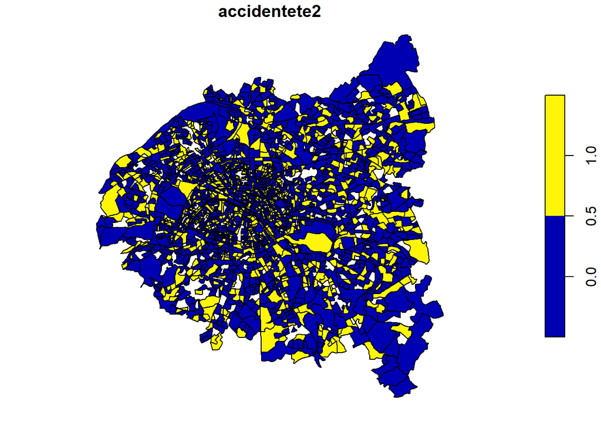

```r
acc_spatialIRISPARISete2 <-acc_spatialIRISPARISete %>% group_by(CODE_IRIS) %>% summarise(accidentete2= sum(accidentete2!= 0))
plot(acc_spatialIRISPARISete["accidentete2"])
```

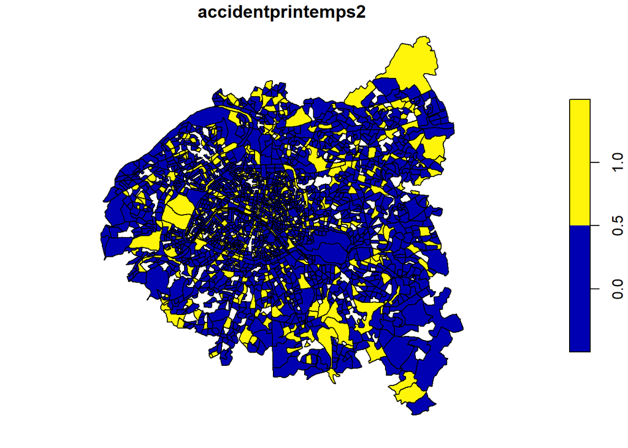

```r
acc_spatialIRISPARISprint2 <-acc_spatialIRISPARISprint %>% group_by(CODE_IRIS) %>% summarise(accidentprintemps2= sum(accidentprintemps2!= 0))
plot(acc_spatialIRISPARISprint["accidentprintemps2"])
```

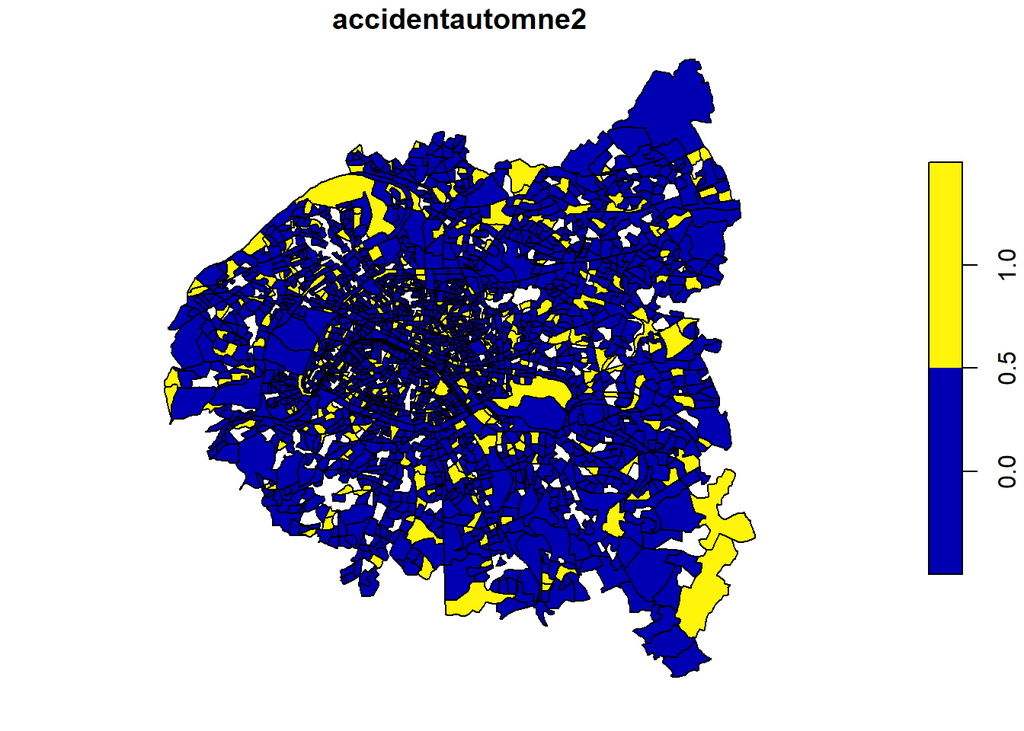

```r
acc_spatialIRISPARISauto2 <-acc_spatialIRISPARISauto %>% group_by(CODE_IRIS) %>% summarise(accidentautomne2= sum(accidentautomne2!= 0))
plot(acc_spatialIRISPARISauto["accidentautomne2"])
```

La dernière étape fut d’afficher le résultat en 4 cartes (1 carte = 1 saison) :

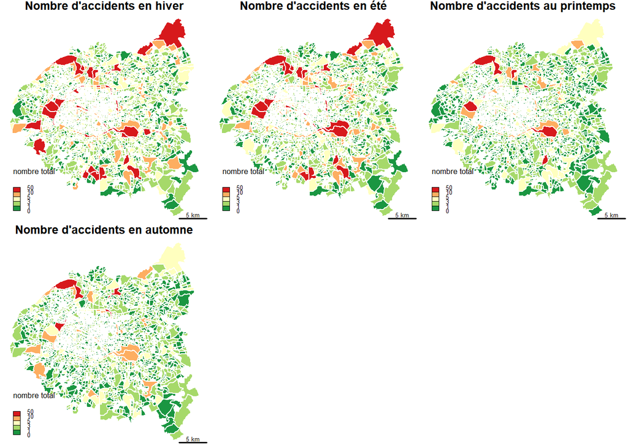

```r
par(mar=c(0,0,0.9,0))

par(mfrow=c(2,3))

choroLayer(
  x = acc_spatialIRISPARIShiver2,
  var = "accidenthiver",
  breaks = c(0, 1, 3, 5, 10, 50),
  border ="white",
  col = c("#1a9641", "#a6d96a", "#ffffbf", "#fdae61", "#d7191c"),
  legend.title.txt = "nombre total")
  barscale(size = 5)
  title(main = "Nombre d'accidents en hiver")

choroLayer(
  x = acc_spatialIRISPARISete2,
  var = "accidentete2",
  breaks = c(0, 1, 3, 5, 10, 50),
  border ="white",
  col = c("#1a9641", "#a6d96a", "#ffffbf", "#fdae61", "#d7191c"),
  legend.title.txt = "nombre total")
  barscale(size = 5)
  title(main = "Nombre d'accidents en été")

choroLayer(
  x = acc_spatialIRISPARISprint2,
  var = "accidentprintemps2",
  breaks = c(0, 1, 3, 5, 10, 50),
  border ="white",
  col = c("#1a9641", "#a6d96a", "#ffffbf", "#fdae61", "#d7191c"),
  legend.title.txt = "nombre total")
  barscale(size = 5)
  title(main = "Nombre d'accidents au printemps")


choroLayer(
  x = acc_spatialIRISPARISauto2,
  var = "accidentautomne2",
  breaks = c(0, 1, 3, 5, 10, 50),
  border ="white",
  col = c("#1a9641", "#a6d96a", "#ffffbf", "#fdae61", "#d7191c"),
  legend.title.txt = "nombre total")
  barscale(size = 5)
  title(main = "Nombre d'accidents en automne")
```

### Carte bivariée présentant le nombre d’accidents en fonction du niveau de vie à Paris

- Importation du tableur sur le niveau de vie

```r
niveau_vie <- read.csv("BASE_TD_FILO_DEC_IRIS_2018.csv", encoding="UTF-8", sep=";")
```

- Jointure attributaire entre le CSV sur le revenu médian et le SHP où il y a l’informaton du nombre d’accidents par IRIS

```r
bivar <- merge(okm, niveau_vie, by.x = c("CODE_IRIS"), by.y = c("X.U.FEFF.IRIS"))
```

- Reclassification du niveau de vie de A à C (A = Niveau de vie faible, C = niveau de vie élevé)

```r
bivar <-bivar %>% mutate(reclassniv = case_when(niv_vie <= 20000 ~ 'A', niv_vie >=20001 & niv_vie <= 35000~ 'B', niv_vie >=  35001 ~ 'C'))
```

- Reclassification du nombre d’accident de 1 à 3 (1 = nombre d’accident faible, 3 = nombre d’accident élevé)

```r
bivar <- bivar %>% mutate(reclassacc = case_when(accidents <= 10 ~ '1', accidents >=11 & accidents <= 50~ '2', accidents >=  51 ~ '3'))
```

- On réunit les deux champs (reclassification du niveau de vie et reclassification du nombre d’accident)

```r
bivar$concatok<- paste(bivar$reclassacc, bivar$reclassniv, sep = "")
```

- On reclassifie le champs qui vient d’être regroupé afin que ce soit compréhensible dans la légende

```r
bivar <-bivar %>% mutate(bivarok = case_when(concatok == "3C" ~ "Niveau de vie élevé et accidents élevés",
                                             concatok == "3B"~ "Niveau de vie moyen et accidents élevés",
                                             concatok ==  "3A" ~ "Niveau de vie faible et accidents élevés",
                                             concatok == "2C" ~  "Niveau de vie élevé et accidents moyen",
                                             concatok == "2B" ~  "Niveau de vie moyen et accidents moyen",
                                             concatok == "2A" ~  "Niveau de vie faible et accidents moyen",
                                             concatok == "1C" ~  "Niveau de vie élevé et accidents faible",
                                             concatok == "1B" ~  "Niveau de vie moyen et accidents faible",
                                             concatok == "1A" ~  "Niveau de vie faible et accidents faible"))
```

- Existe t-il un lien entre le niveau de vie et les accidents corporels dans Paris et sa petite couronne ?

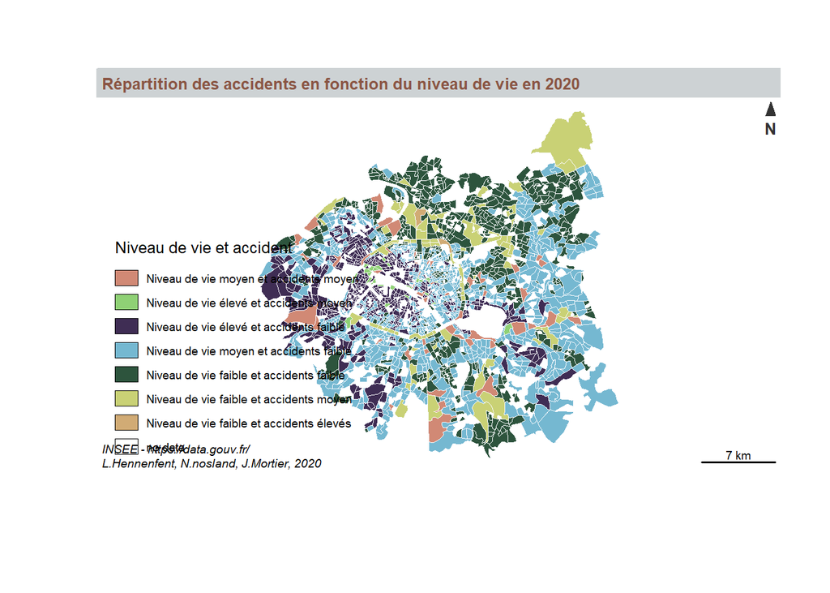

```r
typoLayer(bivar, var = "bivarok",
          border = "#F9FAFD",
          lwd = 0.5,
          col = c("#d18975", "#8fd175", "#3f2d54", "#75b8d1", "#2d543d", "#c9d175", "#d1ab75", "#d175b8", "#758bd1"),

          legend.title.txt = "Niveau de vie et accident")

layoutLayer(title = "Répartition des accidents en fonction du niveau de vie en 2020",
          sources = "INSEE - https://data.gouv.fr/",
          author = "L.Hennenfent, N.nosland, J.Mortier, 2020",  north = TRUE,
          frame = FALSE, col = "#cdd2d4", coltitle = "#8A5543")
```

* Représentation des accidents avec piétons dans Paris et sa petite couronne

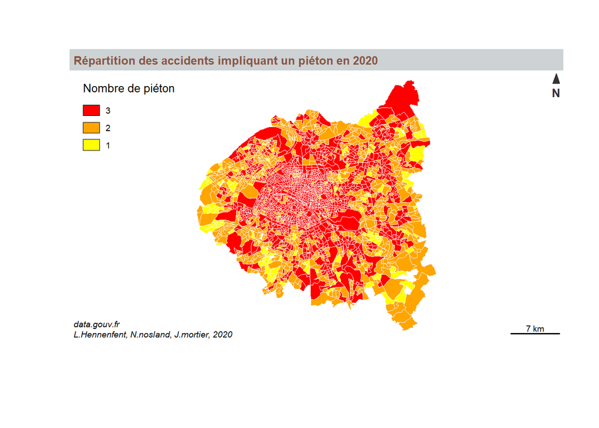

```r
acc_spatialIRISPARIS <- st_join(irisparis, acc_spatial)
parisokkk <- acc_spatialIRISPARIS %>% filter(dep == '75'| dep == '92' | dep == '93'| dep == '94')

iris_piet <-parisokkk %>% group_by(CODE_IRIS) %>% summarise(pieton_imp = sum(pieton))
iris_piet <-iris_piet %>% mutate(cat = case_when(pieton_imp == 0  ~ 1 ,
                                                 pieton_imp > 0 & pieton_imp<= 3 ~ 2,
                                                 pieton_imp > 3 ~ 3,
                                                 TRUE  ~ 0))
iris_piet$cat <- as.numeric(iris_piet$cat)
typoLayer(iris_piet, var = "cat",
          border = "#F9FAFD",
          lwd = 0.5,
          col = c("red", "orange", "yellow"),
          legend.pos = "topleft",
          legend.title.txt = "Nombre de piéton")

layoutLayer(title = "Répartition des accidents impliquant un piéton en 2020",
            sources = "data.gouv.fr",
            author = "L.Hennenfent, N.nosland, J.mortier, 2020",  north = TRUE,
            frame = FALSE, col = "#cdd2d4", coltitle = "#8A5543")
```